# Desafio

Igor Galhano - Turma 22.1

Matheus Da Silva-Martins - Turma 22.1

Reuben Solomon Katz - Turma 22.1

2019-08-09

> Estimando o número $e$ via Simulação de Monte Carlo

## Enunciado do problema

Sem dúvida, os dois números transcedentais mais importantes são $\pi$ e o número de Euler, e. Existem várias maneiras de calcular os valores de tais constantes, sendo as mais famosas baseadas em expansões em séries de Taylor:

$$\frac{\pi}{4} = 1 - \frac{1}{3} + \frac{1}{5} - \frac{1}{7} + \frac{1}{9} - \ldots$$

$$e = \frac{1}{0!} + \frac{1}{1!} + \frac{1}{2!} + \frac{1}{3!} + \ldots$$

É possível estimar o valor da constante $\pi$ através de um experimento aleatório conhecido como o problema de agulha de buffon, o que pode ser implementado em uma simulação de Monte Carlo.

Aqui, iremos estimar de maneira estocástica o número $e$.

## Estratégia da solução

Os seguintes passos serão tomados para resolução do problema:

- Dividir o intervalo real [0,1] em N subintervalos de mesmo comprimento;
- Gerar N números aleatórios uniformemente distribuídos entre 0 e 1;
- Alocar cada um dos números aleatórios gerados ao subintervalo a que pertence;
- Contar a quantidade (Z) de subintervalos que não contém nenhum dos números aleatórios gerados;
- A razão Z/N estima P[0], pois corresponde à frequência relativa de que nenhum dardo acerte um dado segmento da linha. Portanto, podemos estimar a constante e fazendo:

$$e = \frac{N}{Z}$$

### Passo 1: Dividir em um intervalo real

#### Colcoar o número de dardos

```r
rm(list=ls())

n <- 1000
```

### Passo 2: Criando vetor com os números aleatórios e o vetor de ‘N’ intervalos

#### Criando vetor de números aleatórios

```r
darts <- runif(n, min=0, max=1)
```

#### Criando vetor com os ‘N’ intervalos inicialmente todos com zero acertos

```r
hits <- numeric(n)
```

### Passo 3: Encontrando a quantidade de dardos em cada intervalo

```r
for (i in 1:n)
{
  intervalo = as.integer(darts[i]*n)
  hits[intervalo+1] = hits[intervalo+1] +1
}
```

### Passo 4: Calculando quantos intervalos vazios(Z) existem no vetor de intervalos e encontrando o valor de e

```r
z <- 0

for (hit in hits)
{
  if(hit == 0){
    z <- z +1
  }
}
```

### Passo 5: Encontrando a razão Z/N

```r
e <- n/z
```

### Fazendo repetições [(método de monte carlos)](https://pt.wikipedia.org/wiki/M%C3%A9todo_de_Monte_Carlo) para obter amostragens aleatórias e plotando os resultados

Para utilizar o método MMC basta fazer o mesmo processo descrito acima por um número determinado de vezes. A partir de agora, não haverá comentários no códigos, pelo fato de já ter tido comentário acima.

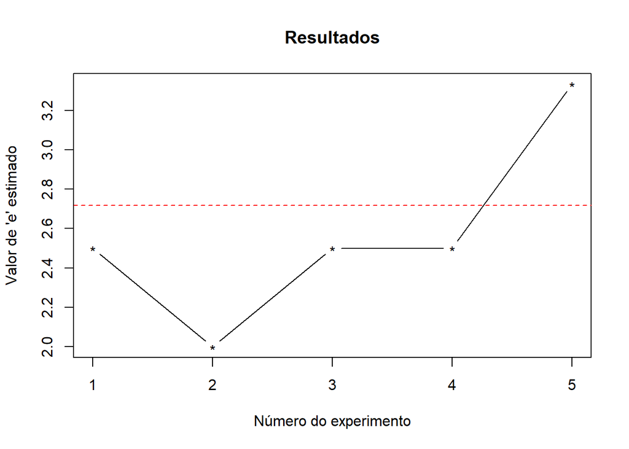

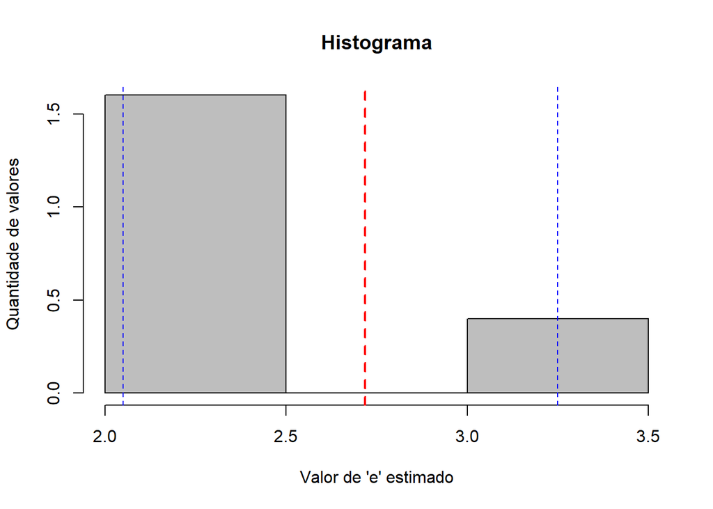

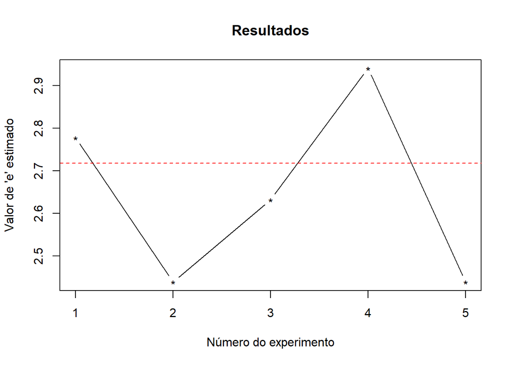

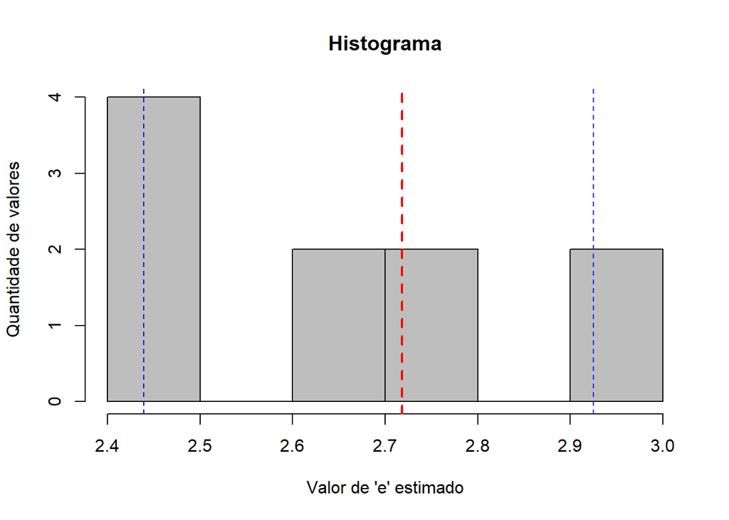

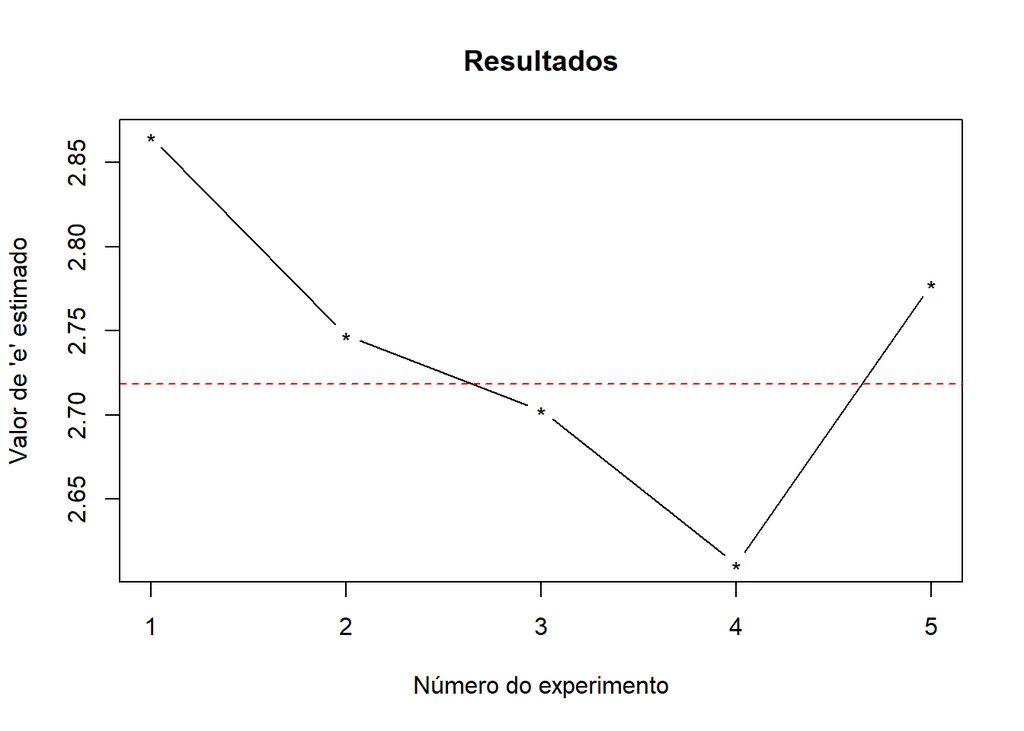

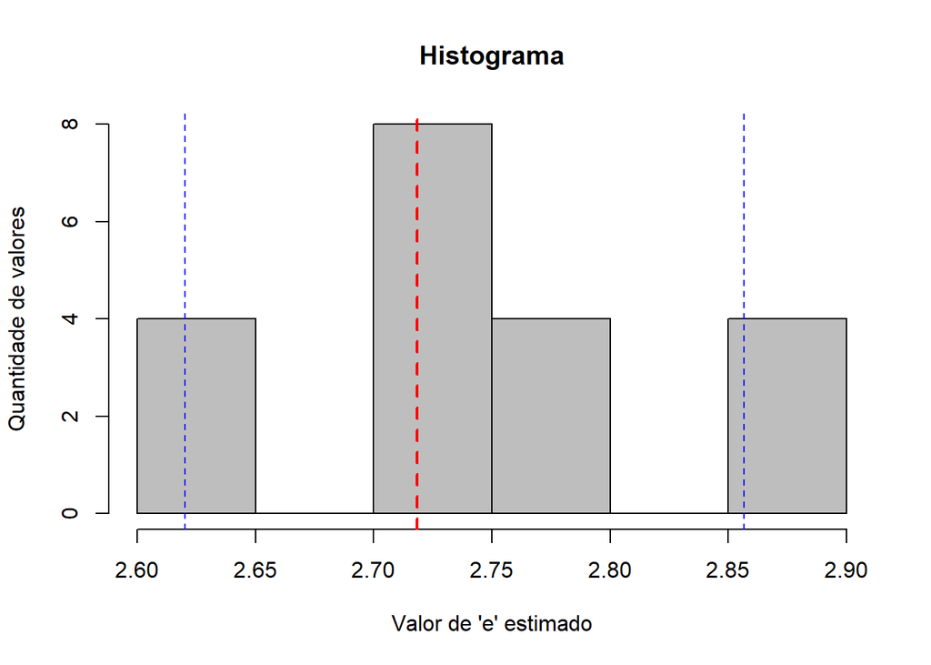

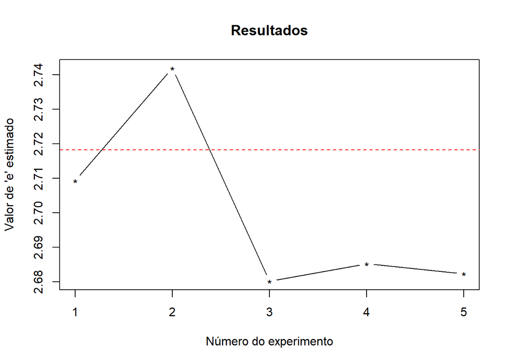

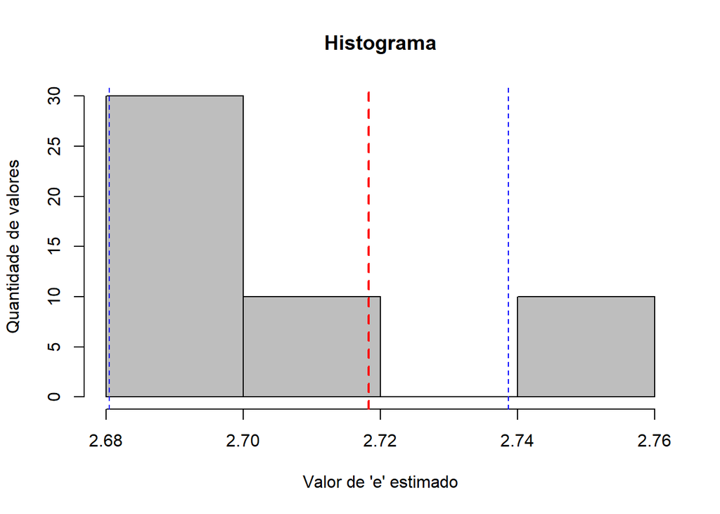

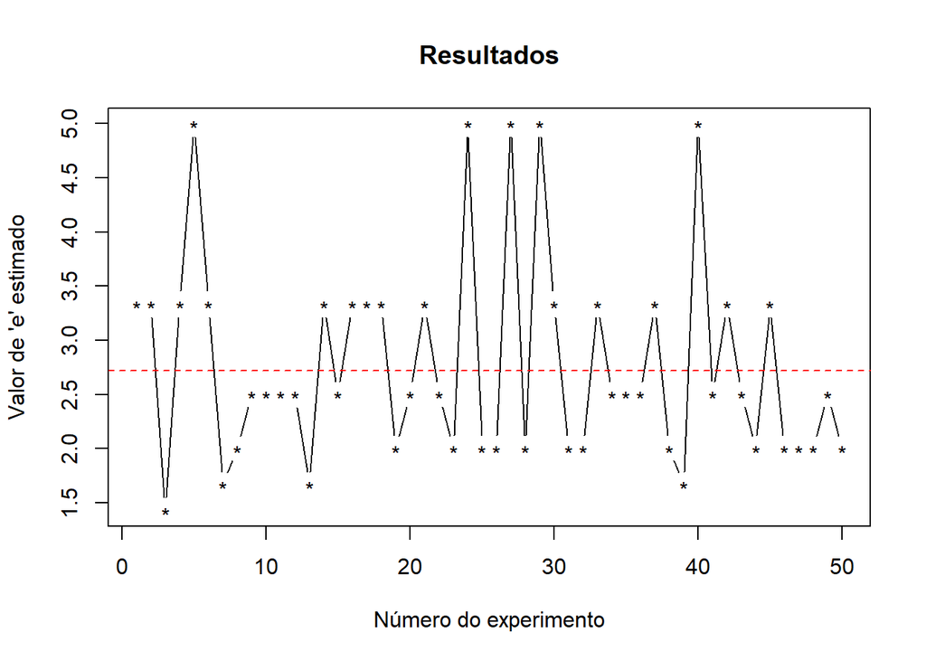

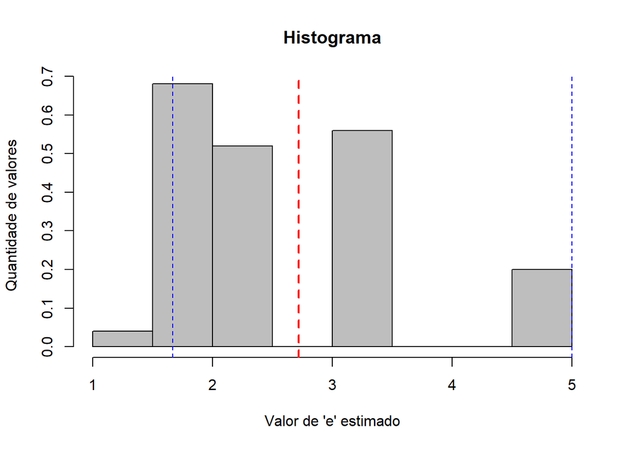

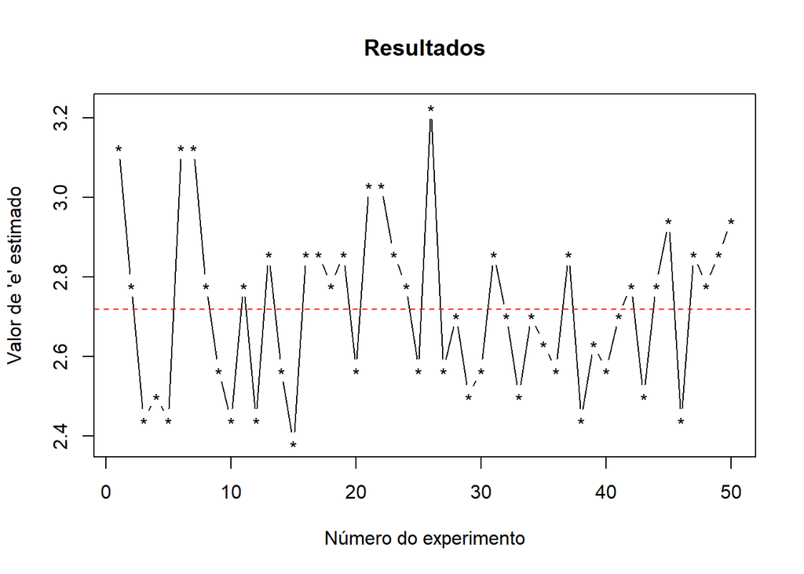

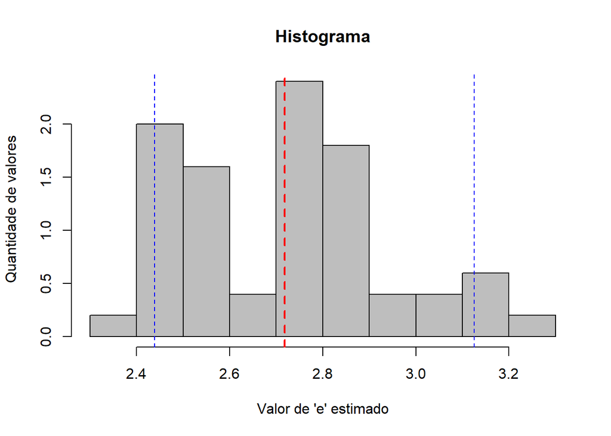

[20 more figures not shown]

```r
rm(list=ls())

n <- c(10, 100, 1000, 10000)

nrep <- c(5, 50, 500, 5000)



for(k in nrep){
  for(m in n){

    results <- numeric(k)

    for(rep in 1:k){

      darts <- runif(m, min=0, max=1)

      hits <- numeric(m)

      intervalo = as.integer(darts*m)

      hits[intervalo] = hits[intervalo] +1

      z <- 0

      for (p in 1:m)
      {
        if(hits[p] == 0){
          z <- z +1
        }
      }

      results[rep] = m/z
    }
    plot(
     results,
     type="b",
     pch = "*",
     xlab="Número do experimento",
     ylab="Valor de 'e' estimado",
     main = "Resultados"
    )
    abline(h = exp(1), col=2 , lty="dashed") # adiciona linha vermelha

    hist(
         results,
         xlab="Valor de 'e' estimado",
         ylab="Quantidade de valores",
         freq = FALSE,
         col = "gray",
         main = "Histograma")
    abline(v = exp(1), col = "red", lty = "dashed", lwd = 2) # adiciona linha vermelha
    # com valor real de 'e'

    abline(v = c(quantile(results, probs=c(0.025, 0.975))),
           col = "blue", lty = "dashed") # 95% das estimativas de 'e' encontram-se entre os valores representados pelas linhas azuis
  }
}
```

## Resultados e Análises

- O que acontece com a distribuição dos valores estimados de e se aumentarmos o número de dardos lançados (micro-experimento), mantendo o número de replicações do (macro) experimento constante?

  Ao aumentar o número de dardos, aumenta-se a precisão dos resultados para cada micro-experimento, conforme comprovado pelos resultados. Isto ocore pois, quanto maior o número de eventos aleatórios, mais próxima a distribuição dos resultados fica em relação às respectivas probabilidades do evento.
- O que acontece com a distribuição dos valores estimados de e se mantivermos constante o número de dardos lançados (micro-experimento) e aumentarmos o número de replicações do (macro) experimento constante?